# R Notebook

ECE 608 (Spring 2019) Assignment 1. Professor: Jason Au Student: Juan Manuel Gomez Gonzalez UW Student ID: 20805369

# Question 1

1. Read in .csv data from the github address into a data frame (call it ‘bg’) and print the structure of the data so you can see an overview at a glance. • To quickly appreciate the scope of the dataset, use ggplot2 to create a geom_point plot of the ‘average_rating’ (y-axis) against the ‘year_published’ (xaxis) and colour the data in red with a transparency (i.e., alpha value) gradient to represent how many users rated the game (‘users_rated’ variable; i.e., ratings based on less users have more transparent points). • Repeat this plot with geom_jitter and display both plots together side-by-side using the grid.arrange function from the gridExtra package. What is the difference between plots and when would one be more appropriate? [5 marks]

## Solution

It is necessary to load the tidyverse and gridExtra libraries in order to be able to use them during the solution of this assignment. The grid library is also needed in order to create the caption for the third question.

```r
library(tidyverse)
library(grid)
library(gridExtra)
```

```r
bg <- read_csv("https://raw.githubusercontent.com/rfordatascience/tidytuesday/master/data/2019/2019-03-12/board_games.csv", col_types = cols_only(
game_id = col_integer(),
#description = col_character(),
#image = col_character(),
max_players = col_integer(),
max_playtime = col_integer(),
min_age = col_integer(),
min_players = col_integer(),
min_playtime = col_integer(),
name = col_character(),
playing_time = col_integer(),
#thumbnail = col_character(),
year_published = col_integer(),
artist = col_character(),
category = col_character(),
compilation = col_character(),
designer = col_character(),
expansion = col_character(),
family = col_character(),
mechanic = col_character(),
publisher = col_character(),
average_rating = col_double(),
users_rated = col_integer()))
```

It is possible to use “dplyr::tbl_df()” to display the information in bg as a table, but as it contains a considerable amount of characters for some of its variables, it can be computationally expensive to display. Therefore, it is more appropriate to display it using “dplyr::glimpse()”.

```r
#dplyr::tbl_df(bg)
dplyr::glimpse(bg)
```

```
## Rows: 10,532
## Columns: 19
## $ game_id        <int> 1, 2, 3, 4, 5, 6, 7, 8, 9, 10, 11, 12, 13, 14, 15, 16,…
## $ max_players    <int> 5, 4, 4, 4, 6, 6, 2, 5, 4, 6, 7, 5, 4, 4, 6, 4, 2, 8, …
## $ max_playtime   <int> 240, 30, 60, 60, 90, 240, 20, 120, 90, 60, 45, 60, 120…
## $ min_age        <int> 14, 12, 10, 12, 12, 12, 8, 12, 13, 10, 13, 12, 10, 10,…
## $ min_players    <int> 3, 3, 2, 2, 3, 2, 2, 2, 2, 2, 2, 2, 3, 3, 2, 3, 2, 2, …
## $ min_playtime   <int> 240, 30, 30, 60, 90, 240, 20, 120, 90, 60, 45, 45, 60,…
## $ name           <chr> "Die Macher", "Dragonmaster", "Samurai", "Tal der Köni…
## $ playing_time   <int> 240, 30, 60, 60, 90, 240, 20, 120, 90, 60, 45, 60, 120…
## $ year_published <int> 1986, 1981, 1998, 1992, 1964, 1989, 1978, 1993, 1998, …
## $ artist         <chr> "Marcus Gschwendtner", "Bob Pepper", "Franz Vohwinkel"…
## $ category       <chr> "Economic,Negotiation,Political", "Card Game,Fantasy",…
## $ compilation    <chr> NA, NA, NA, NA, NA, NA, NA, NA, NA, NA, NA, NA, "CATAN…
## $ designer       <chr> "Karl-Heinz Schmiel", "G. W. \"Jerry\" D'Arcey", "Rein…
## $ expansion      <chr> NA, NA, NA, NA, NA, NA, NA, NA, NA, "Elfengold,Elfenla…
## $ family         <chr> "Country: Germany,Valley Games Classic Line", "Animals…
## $ mechanic       <chr> "Area Control / Area Influence,Auction/Bidding,Dice Ro…
## $ publisher      <chr> "Hans im Glück Verlags-GmbH,Moskito Spiele,Valley Game…
## $ average_rating <dbl> 7.66508, 6.60815, 7.44119, 6.60675, 7.35830, 6.52534, …
## $ users_rated    <int> 4498, 478, 12019, 314, 15195, 73, 2751, 186, 1263, 672…
```

The “head()” function can also be used to visualize the first elements of the dataset:

```r
head(bg)
```

| game_id | max_players | max_playtime | min_age | min_players | min_playtime | name | playing_time | year_published | artist | category | compilation | designer | expansion | family | mechanic | publisher | average_rating | users_rated |
| --- | --- | --- | --- | --- | --- | --- | --- | --- | --- | --- | --- | --- | --- | --- | --- | --- | --- | --- |
| 1 | 5 | 240 | 14 | 3 | 240 | Die Macher | 240 | 1986 | Marcus Gschwendtner | Economic,Negotiation,Political | NA | Karl-Heinz Schmiel | NA | Country: Germany,Valley Games Classic Line | Area Control / Area Influence,Auction/Bidding,Dice Rolling,Hand Management,Simultaneous Action Selection | Hans im Glück Verlags-GmbH,Moskito Spiele,Valley Games, Inc. | 7.66508 | 4498 |
| 2 | 4 | 30 | 12 | 3 | 30 | Dragonmaster | 30 | 1981 | Bob Pepper | Card Game,Fantasy | NA | G. W. "Jerry" D'Arcey | NA | Animals: Dragons | Trick-taking | E.S. Lowe,Milton Bradley | 6.60815 | 478 |
| 3 | 4 | 60 | 10 | 2 | 30 | Samurai | 60 | 1998 | Franz Vohwinkel | Abstract Strategy,Medieval | NA | Reiner Knizia | NA | Asian Theme,Country: Japan,Knizia tile-laying trilogy,Samurai | Area Control / Area Influence,Hand Management,Set Collection,Tile Placement | 999 Games,ABACUSSPIELE,Astrel Games,Ceilikan Jogos,Descartes Editeur,Edge Entertainment,Fantasy Flight Games,Galakta,Hans im Glück Verlags-GmbH,Hobby Japan,Lacerta,Lautapelit.fi,Rio Grande Games,Skand… | 7.44119 | 12019 |
| 4 | 4 | 60 | 12 | 2 | 60 | Tal der Könige | 60 | 1992 | NA | Ancient | NA | Christian Beierer | NA | Country: Egypt,Promotional Board Games | Action Point Allowance System,Area Control / Area Influence,Auction/Bidding,Set Collection | KOSMOS | 6.60675 | 314 |
| 5 | 6 | 90 | 12 | 3 | 90 | Acquire | 90 | 1964 | Scott Okumura,Peter Whitley | Economic | NA | Sid Sackson | NA | 3M Bookshelf Series | Hand Management,Stock Holding,Tile Placement | 3M,Avalon Hill,Avalon Hill (Hasbro),Dujardin,Grow Jogos e Brinquedos,PS-Games,Schmidt France,Schmidt International,Schmidt Spiele,Selecta Spel en Hobby,Smart Games, Inc. | 7.35830 | 15195 |
| 6 | 6 | 240 | 12 | 2 | 240 | Mare Mediterraneum | 240 | 1989 | Jean du Poël | Civilization,Nautical | NA | Jean du Poël | NA | Cities: Marseille | Dice Rolling | Historien Spiele Galerie (Historien Spielegalerie) | 6.52534 | 73 |

The dataset seems to be comprised of information related to a list of board games with attributes like the name of the game, how many players can play the game simultaneously, etc. The first part of the assignment asks for the creation of two scatterplots (with and without an added jitter) in which the x axis indicates the year of publication of the game, while the average rating of it is displayed in the y axis. The number of users that rate the game also need to be displayed, as a z axis in the form of the transparency of each data point in the plot.

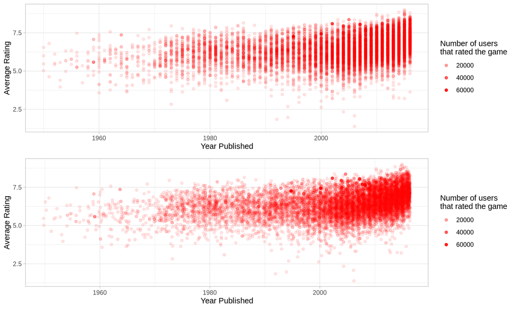

```r
plot_base <- ggplot(bg, aes(year_published, average_rating, alpha = users_rated)) + labs(x = "Year Published", y = "Average Rating", alpha='Number of users\nthat rated the game')
plotScatter <-  plot_base + geom_point(colour = "red") + theme_light()
plotJitter <-  plot_base + geom_jitter(colour = "red") + theme_light()
grid.arrange(plotScatter, plotJitter, nrow = 2, ncol = 1)
```

The correct way of displaying the data is the first plot (using no jitter) as the year is the only information available in the data (without the month and day, and thus making all the board games be supposedly released on the same date of each year). However, it would be more realistic to use the plot with jitter as it would reflect how in reality the board games should have been released (during the course of each year instead of at one specific day of it), which would help avoid create certain assumptions from viewing the dataset in such an organized way.

# Question 2

To explore this dataset further, you will have to clean up the ‘category’ variable a bit. I would like you to create a new data frame (call it bg2) with the following instructions: • Filter the data so you only include board games that are ‘Card Game’, or ‘Dice’ type games; • Create a new categorical variable called ‘type’ that classifies games into either Card, Dice, or Both; • Plot the following three types of graphs to show ‘type’ on the x-axis and ‘average_rating’ on the y-axis: geom_jitter, geom_boxplot, and geom_violin. Plot these together using the grid.arrange function from the gridExtra package. In a few sentences, describe how each type of plot provides unique information about the dataset. Is one superior to the others? [7 marks]

## Solution

The first step to answer this question is to create bg2, with a filtering applied to the data so that it only contains board games that use Cards or Dice as part of its gameplay. A new variable called type should also be created per the instructions in the second question.

```r
bg2 <- bg %>% filter(str_detect(category, 'Card Game|Dice')) %>%
  mutate(type = ifelse(str_detect(category, 'Card Game') & str_detect(category, 'Dice'), "Both", ifelse(str_detect(category, 'Card Game'), "Card", "Dice")))
dplyr::glimpse(bg2)
```

```
## Rows: 3,702
## Columns: 20
## $ game_id        <int> 2, 11, 17, 28, 41, 44, 49, 50, 64, 72, 73, 74, 75, 89,…
## $ max_players    <int> 4, 7, 2, 8, 4, 6, 5, 2, 6, 4, 6, 10, 8, 4, 2, 6, 6, 5,…
## $ max_playtime   <int> 30, 45, 5, 180, 30, 60, 30, 30, 180, 60, 60, 30, 5, 12…
## $ min_age        <int> 12, 13, 10, 12, 9, 8, 10, 10, 12, 12, 10, 12, 8, 12, 8…
## $ min_players    <int> 3, 2, 2, 2, 2, 3, 2, 2, 3, 3, 2, 4, 4, 2, 2, 2, 2, 3, …
## $ min_playtime   <int> 30, 45, 5, 60, 30, 60, 30, 30, 180, 60, 60, 30, 5, 120…
## $ name           <chr> "Dragonmaster", "Bohnanza", "Button Men", "Illuminati:…
## $ playing_time   <int> 30, 45, 5, 180, 30, 60, 30, 30, 180, 60, 60, 30, 5, 12…
## $ year_published <int> 1981, 1997, 1999, 1987, 1980, 1998, 1999, 1999, 1998, …
## $ artist         <chr> "Bob Pepper", "Fréderic Bertrand,Marek Bláha,Andrea Bo…
## $ category       <chr> "Card Game,Fantasy", "Card Game,Farming,Negotiation", …
## $ compilation    <chr> NA, NA, NA, NA, NA, NA, "Mamma Mia! con Ingredientes d…
## $ designer       <chr> "G. W. \"Jerry\" D'Arcey", "Uwe Rosenberg", "James Ern…
## $ expansion      <chr> NA, "Auf der schwäb'schen Eisenbohn,Bohn Camillo,Bohna…
## $ family         <chr> "Animals: Dragons", "Bohnanza,Lookout Bean Games", "Va…
## $ mechanic       <chr> "Trick-taking", "Hand Management,Set Collection,Tradin…
## $ publisher      <chr> "E.S. Lowe,Milton Bradley", "AMIGO Spiel + Freizeit Gm…
## $ average_rating <dbl> 6.60815, 7.06751, 6.30870, 6.52890, 6.85659, 6.45290, …
## $ users_rated    <int> 478, 28354, 724, 4274, 9095, 1418, 4824, 26686, 409, 1…
## $ type           <chr> "Card", "Card", "Dice", "Card", "Dice", "Card", "Card"…
```

Afterwards, the different graphs can be plotted and compared:

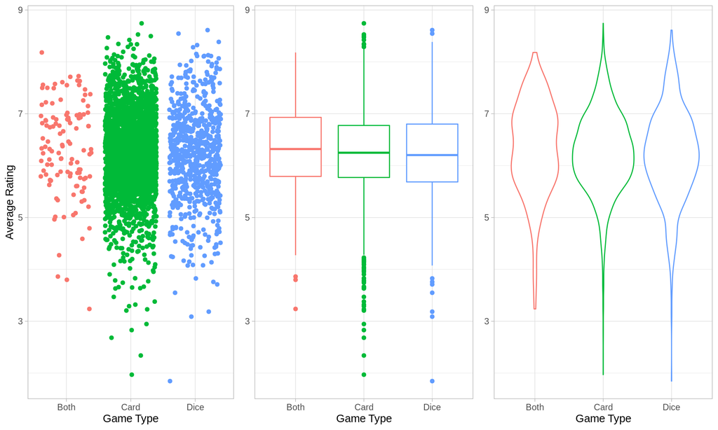

```r
plot_base2 <- ggplot(bg2, aes(type, average_rating, colour = factor(type))) + labs(x = "Game Type", y = "Average Rating")
plotJitter <-  plot_base2 + geom_jitter() + theme_light() + theme(legend.position = "none")
plotBox <-  plot_base2 + geom_boxplot() + theme_light() + theme(legend.position = "none", axis.title.y = element_blank())
plotViolin <-  plot_base2 + geom_violin() + theme_light() + theme(legend.position = "none", axis.title.y = element_blank())
grid.arrange(plotJitter,plotBox,plotViolin, nrow = 1, ncol = 3)
```

The jitter plot allows for the viewing of the data points distribution more clearly, as it represents each datapoint from the set. The boxplot allows for an easier view of the different inter quartile ranges, while also showing information about the outliers of each game type. The violin plot allows for a better view of the data distribution, specifically its density, because it shows a representation for where each datapoint is located similar to the jitter plot, but without saturating the plot. According to these statements, there is not necessarily one that is better than the rest, and it can be considered that each has its own advantages. It is up to the person conveying the information to select the correct plot to use in order to express appropriately their results.

# Question 3

Finally, manipulate the original data to answer your own question in this generic format: Ranking the games from best (1) to worst (10,532) based on their average_rating, are games that are [condition] ranked higher than [condition]? (e.g., are games longer than 120 minutes ranked higher than games shorter than 120 minutes?) Be creative! Create one plot using ggplot2 to represent this question. To make this a publishable plot, make sure to have: • Labelled axes and axis units (if applicable) • Legend • Appropriate graph type • Appropriate axis scales • Accompanying Figure caption in your R Notebook (something similar to what you would see in a research paper underneath a figure). [5 marks]

## Solution

For this question, bg3 is created with a ranking implemented using the average_rating. The sorting (“arrange”) is not really needed, but it helps in the visualization of the coincidence of the ranking and the largest average rating.

```r
bg3 <- bg  %>%
  arrange(desc(average_rating)) %>%
  #mutate(ranking = dplyr::row_number()) %>%
  #mutate(ranking = dplyr::min_rank(desc(average_rating))) %>%
  mutate(ranking = dplyr::dense_rank(desc(average_rating))) %>%
  mutate(category_number = ifelse(is.na(category), as.double(0), str_count(category, ",") + 1)) %>%
  mutate(expansion_number = ifelse(is.na(expansion), as.double(0), str_count(expansion, ",") + 1)) %>%
  mutate(publisher_number = ifelse(is.na(publisher), as.double(0), str_count(publisher, ",") + 1))
dplyr::glimpse(bg3)
```

```
## Rows: 10,532
## Columns: 23
## $ game_id          <int> 140135, 55690, 181289, 144574, 173504, 178896, 68820…
## $ max_players      <int> 6, 6, 5, 2, 8, 4, 2, 4, 7, 4, 2, 5, 4, 8, 0, 4, 4, 2…
## $ max_playtime     <int> 80, 180, 150, 60, 6000, 960, 600, 240, 540, 60, 0, 1…
## $ min_age          <int> 8, 17, 12, 15, 12, 13, 0, 14, 16, 13, 0, 15, 12, 16,…
## $ min_players      <int> 2, 1, 2, 2, 2, 2, 1, 2, 3, 2, 1, 1, 2, 2, 2, 2, 2, 1…
## $ min_playtime     <int> 40, 60, 60, 60, 60, 180, 0, 180, 360, 60, 0, 40, 180…
## $ name             <chr> "Small World Designer Edition", "Kingdom Death: Mons…
## $ playing_time     <int> 80, 180, 150, 60, 6000, 960, 600, 240, 540, 60, 0, 1…
## $ year_published   <int> 2015, 2015, 2015, 2014, 2015, 2016, 2015, 2015, 2010…
## $ artist           <chr> "Miguel Coimbra,Cyrille Daujean", "Lokman Lam,Lorind…
## $ category         <chr> "Civilization,Fantasy,Territory Building", "Adventur…
## $ compilation      <chr> "Small World,Small World: 6 Player Board,Small World…
## $ designer         <chr> "Philippe Keyaerts", "Adam Poots", "Jens Drögemüller…
## $ expansion        <chr> NA, "Kingdom Death: Monster – A Strange Spot and Bel…
## $ family           <chr> "Crowdfunding: Kickstarter,Small World", "Campaign G…
## $ mechanic         <chr> "Area Control / Area Influence,Area Movement,Dice Ro…
## $ publisher        <chr> "Days of Wonder", "Kingdom Death", "Feuerland Spiele…
## $ average_rating   <dbl> 9.00392, 8.93184, 8.84862, 8.84603, 8.83081, 8.80263…
## $ users_rated      <int> 180, 1954, 109, 88, 86, 76, 187, 6888, 165, 17251, 7…
## $ ranking          <int> 1, 2, 3, 4, 5, 6, 7, 8, 9, 10, 11, 12, 13, 14, 15, 1…
## $ category_number  <dbl> 3, 6, 4, 3, 2, 2, 2, 3, 3, 2, 2, 3, 7, 2, 2, 5, 2, 2…
## $ expansion_number <dbl> 0, 54, 0, 0, 0, 0, 0, 0, 1, 0, 0, 0, 0, 1, 0, 0, 1, …
## $ publisher_number <dbl> 1, 1, 3, 1, 1, 1, 1, 11, 3, 10, 1, 1, 3, 1, 1, 7, 2,…
```

Interpreting information from a graph can be somewhat difficult when the data is nos sufficiently sparse. In this specific case, the majority of the variables have a condensed density (possibly because the data has some outliers), making the visualization of the rest of the data more difficult. An example of this can be seen in Figures 1 to 3.

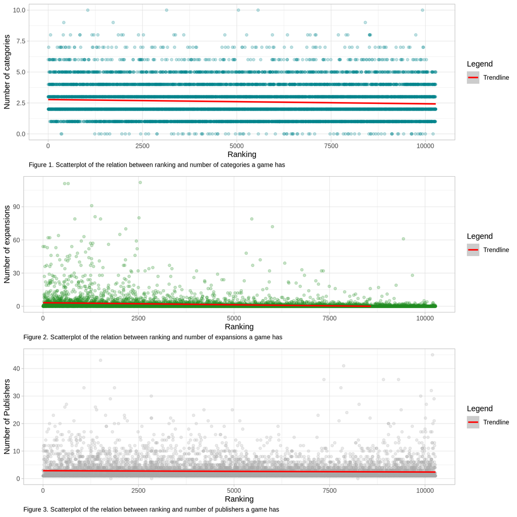

```r
# First find the limits for the scales of the different plots (pseudo outlier removal)
n <- length(bg3$category_number) #Find the length of the df
nth_number = n - 6 # Number of outliers to remove. If n-1, use second largest value, if n-2 use third largest value, and so on
cat_num_lim=sort(bg3$category_number,partial=nth_number)[nth_number] #Find the second largest value of category_number
exp_num_lim=sort(bg3$expansion_number,partial=nth_number)[nth_number] #Find the second largest value of expansion_number
pub_num_lim=sort(bg3$publisher_number,partial=nth_number)[nth_number] #Find the second largest value of publisher_number

#Then create the plots with the limits
plot_base_cat <- ggplot(bg3, aes(x = ranking, y = category_number, colour = Legend)) + labs(y= "Number of categories", x = "Ranking", caption = 'Figure 1. Scatterplot of the relation between ranking and number of categories a game has') + ylim(0, cat_num_lim)
plotScatter_category <-  plot_base_cat + geom_point(colour = "turquoise4", alpha=0.25) + geom_smooth(aes(colour = "Trendline"), method = "lm", alpha = 0.5) +
  scale_colour_manual(values = "Red") + theme_light() + theme(plot.caption = element_text(hjust = 0))

plot_base_exp <- ggplot(bg3, aes(x = ranking, y = expansion_number, colour = Legend)) + labs(y= "Number of expansions", x = "Ranking", caption = 'Figure 2. Scatterplot of the relation between ranking and number of expansions a game has') + ylim(0, exp_num_lim)
plotScatter_expansion <-  plot_base_exp + geom_point(colour = "forestgreen", alpha=0.25) + geom_smooth(aes(colour = "Trendline"), method = "lm", alpha = 0.5) +
  scale_colour_manual(values = "Red") + theme_light() + theme(plot.caption = element_text(hjust = 0))

plot_base_pub <- ggplot(bg3, aes(x = ranking, y = publisher_number, colour = Legend)) + labs(y= "Number of Publishers", x = "Ranking", caption = 'Figure 3. Scatterplot of the relation between ranking and number of publishers a game has') + ylim(0, pub_num_lim)
plotScatter_publisher <-  plot_base_pub + geom_point(colour = "darkgray", alpha=0.25) + geom_smooth(aes(colour = "Trendline"), method = "lm", alpha = 0.5) +
  scale_colour_manual(values = "Red") + theme_light() + theme(plot.caption = element_text(hjust = 0))

#Then plot them
grid.arrange(plotScatter_category,plotScatter_expansion,plotScatter_publisher, nrow=3, ncol=1)
```

Moreover, there seems to be no discernible pattern in the data, except for the case of year of publishing. Based on this, an interesting question can then be formulated as: Are the games published after the year 2000 better ranked than the games created before the second millennium?

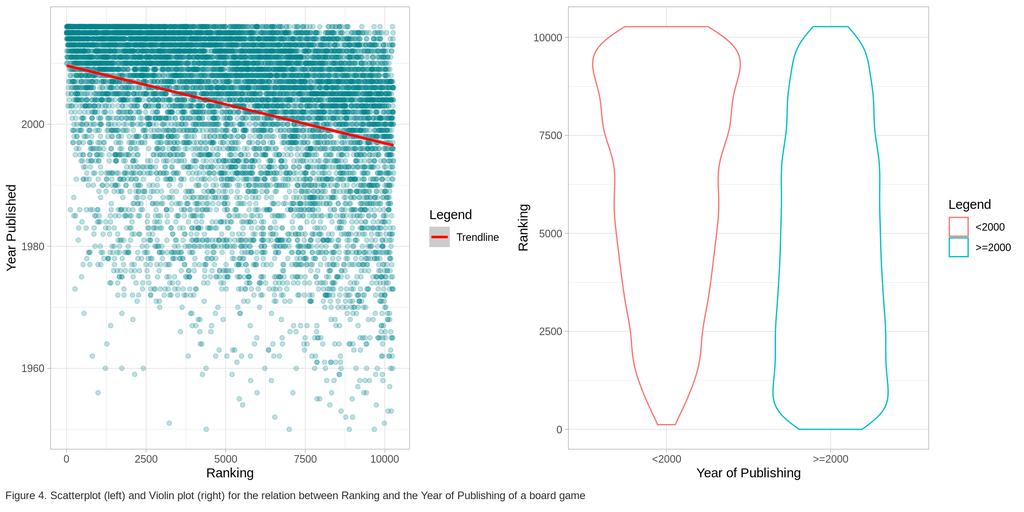

```r
# Create the new variable
bg3 <- bg3 %>%
  mutate(after2k = ifelse(year_published>=2000, ">=2000", "<2000"))
# Create the scatter plot
plot_base3 <- ggplot(bg3, aes(x = ranking, y = year_published)) + theme_light()
plotScatter <-  plot_base3 + geom_point(colour = "turquoise4", alpha=0.25) + geom_smooth(aes(colour = "Trendline"), method = "lm", alpha = 0.5) +
  scale_colour_manual(values = "Red") + labs(y= "Year Published", x = "Ranking", colour = "Legend") + theme_light()

# Create the violin plot
plot_base3 <- ggplot(bg3, aes(x = after2k, y = ranking , colour = factor(after2k))) + theme_light()
plotViolin <-  plot_base3 + geom_violin() + labs(x = "Year of Publishing", y = "Ranking", colour = "Legend")

# Create the caption. This part is based on an answer given by hrbmstr in StackOverflow: https://stackoverflow.com/a/41106250
figCaption <- textGrob("Figure 4. Scatterplot (left) and Violin plot (right) for the relation between Ranking and the Year of Publishing of a board game",
           gp = gpar(fontsize=9, col = "#2b2b2b"),
           x = unit(0.005, "npc"), just = c("left", "bottom"))

# Build the layout
plot_layout <- rbind(c(1,2), c(3,3))

# Plot everything
grid.arrange(plotScatter,plotViolin,figCaption, layout_matrix = plot_layout, heights = c(0.95, 0.05))
```